# 5. Applied Regression III

# 3. Effect modification

- Effect of exposure on outcome modified by a third factor = effect modifier
  - To identify population subgroups with higher (synergism) or lower (antagonism) from intervention
  - Can be evaluated by
    - Stratified analysis
    - Fitting regression model with an interaction term

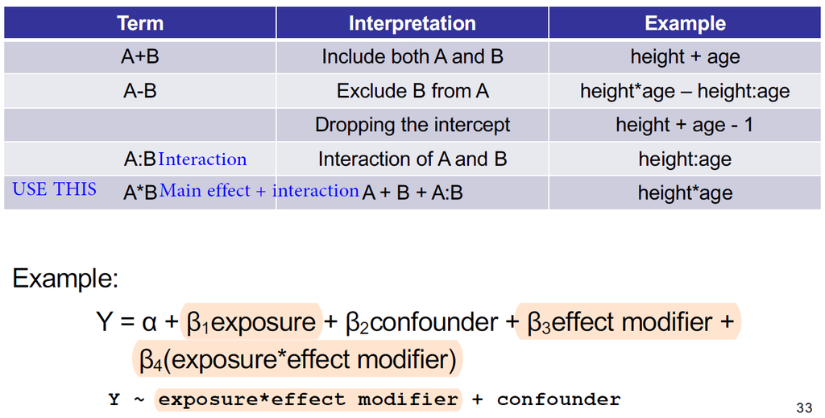

#### Example: Cardiovascular risk in the elderly

Suppose age is a potential effect modifier of the phy effect on sfrs

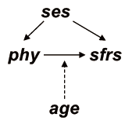

```r
age.int <- lm(sfrs~phy*age+ses, data=cardio)
summary(age.int)
```

```
##
## Call:
## lm(formula = sfrs ~ phy * age + ses, data = cardio)
##
## Residuals:
##      Min       1Q   Median       3Q      Max
## -1.76319 -0.36795 -0.00419  0.38516  1.62703
##
## Coefficients:
##               Estimate Std. Error t value Pr(>|t|)
## (Intercept)  1.051e+01  3.932e-01   26.73   <2e-16 ***
## phy         -1.960e-01  7.169e-03  -27.34   <2e-16 ***
## age         -1.212e-01  5.187e-03  -23.37   <2e-16 ***
## ses          1.504e-01  1.085e-02   13.86   <2e-16 ***
## phy:age      2.008e-03  9.415e-05   21.33   <2e-16 ***
## ---
## Signif. codes:  0 '***' 0.001 '**' 0.01 '*' 0.05 '.' 0.1 ' ' 1
##
## Residual standard error: 0.541 on 995 degrees of freedom
## Multiple R-squared:  0.7084, Adjusted R-squared:  0.7073
## F-statistic: 604.4 on 4 and 995 DF,  p-value: < 2.2e-16
```

```r
## The protective effect of physical activity on cardiovascular risk diminished with older age (antagonism)
# Protective since beta is -ve (-1.960e-01); Dimnished since beta has opposite sign i.e., +ve (2.008e-03)
```

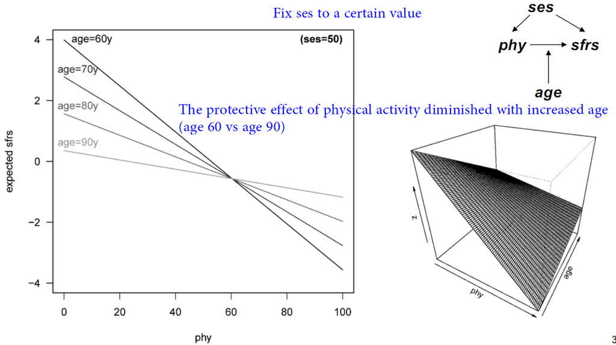

# 4. Mediation

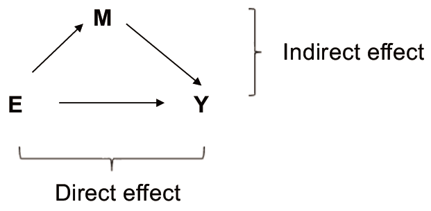

#### Example: Cardiovascular risk in the elderly

Suppose bmi is a potential mediator of the phy effect on sfrs

## 4.1 Baron and Kenny criteria

- Is exposure associated with the mediator? (M~E)
- Is mediator associated with the outcome? (Y~M)
- Is exposure associated with the outcome? (Y~E)
- Does adjusting for the mediator reduce the association between the exposure and the outcome (attenuation) (compare with Y~E+M)
  - Note that the criteria is only valid in some simple situations but is not always valid (discussed in CMED6030)

```r
summary(lm(bmi~phy, data=cardio)) #β = -0.096, p < 0.001
summary(lm(sfrs~bmi, data=cardio)) #β = -0.009, p = 0.130
summary(lm(sfrs~phy, data=cardio)) #βphy = -0.035, p < 0.001
summary(lm(sfrs~phy+bmi, data=cardio)) #βphy’ = -0.041, p < 0.001 (no attenuation)
##BMI doesn't satisfy 2nd and 4th B&K criterion.
```

[output not shown]

## 4.2 Sobel test

- The indirect effect is τ – τ’ = αβ
- Null hypothesis H<sub>0</sub> of sobel test αβ = 0. Can generate z value
  - $z = \frac {αβ} {\sqrt{α^2σ^2_β + β^2σ^2_α}}$ (denominator is sd of αβ)
    - α is obtained by fitting M~E
    - β is obtained by fitting Y~E+M
  - It is a mediator if significance level <5% (z > 1.96)
  - Note:
    - Other versions of Sobel-Goodman test have different forms of the denominator
    - This is for continuous outcomes. A more complicated version is needed for binary outcomes
- `sobel(iv, mv, dv)` (in package: multilevel)
  - **iv** is the independent variable (E)
  - **mv** is the mediator variable (M)
  - **dv** is the dependent variable (Y)

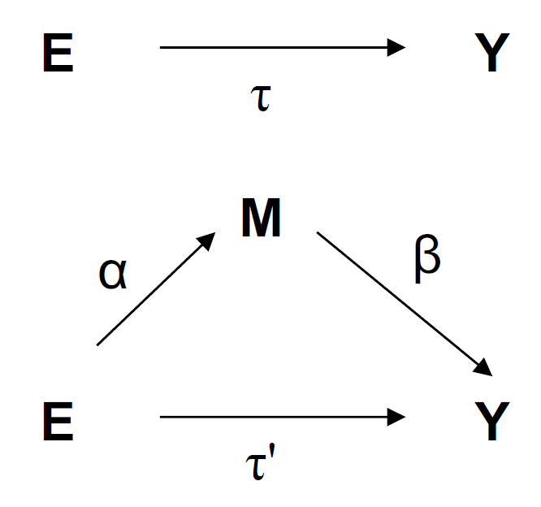

```r
require("multilevel")
out <- with(cardio, sobel(phy, bmi, sfrs)) #(“with” function: use cardio dataset)
2*pnorm(out$z.value, lower.tail=F) #2* to find 2-sided p value; lower.tail=F to find P[X>x] otherwise is P[X≤x].
```

```
## [1] 5.466551e-23
```

```r
## 2 tail pval = 5.466551e-23 < 0.05 => Reject H0. There is significant mediation effect
```

```r
##Self-practice, use sobel test without the package
m1 <- lm(bmi~phy, data=cardio)
m2 <- lm(sfrs~phy+bmi, data=cardio)
summary (m1)
summary (m2)

α <- coef(m1) [2]
αsd <- coef(summary(m1)) [2,2]
β <- coef(m2) [3]
βsd <- coef(summary(m2)) [3,2]
z <- α*β / sqrt(α^2*βsd^2 + β^2*αsd^2)
2*pnorm(z, lower.tail=F)
```

```
##
## Call:
## lm(formula = bmi ~ phy, data = cardio)
##
## Residuals:
##      Min       1Q   Median       3Q      Max
## -15.1595  -3.4379   0.1464   3.4032  13.5325
##
## Coefficients:
##              Estimate Std. Error t value Pr(>|t|)
## (Intercept) 34.867335   0.430006   81.09   <2e-16 ***
## phy         -0.095992   0.007774  -12.35   <2e-16 ***
## ---
## Signif. codes:  0 '***' 0.001 '**' 0.01 '*' 0.05 '.' 0.1 ' ' 1
##
## Residual standard error: 4.983 on 998 degrees of freedom
## Multiple R-squared:  0.1325, Adjusted R-squared:  0.1316
## F-statistic: 152.5 on 1 and 998 DF,  p-value: < 2.2e-16
##
##
## Call:
## lm(formula = sfrs ~ phy + bmi, data = cardio)
##
## Residuals:
##      Min       1Q   Median       3Q      Max
## -2.62195 -0.39702  0.00414  0.39714  2.30706
##
## Coefficients:
##              Estimate Std. Error t value Pr(>|t|)
## (Intercept)  4.081852   0.149553   27.29   <2e-16 ***
## phy         -0.041108   0.001054  -39.01   <2e-16 ***
## bmi         -0.065702   0.003997  -16.44   <2e-16 ***
## ---
## Signif. codes:  0 '***' 0.001 '**' 0.01 '*' 0.05 '.' 0.1 ' ' 1
##
## Residual standard error: 0.6291 on 997 degrees of freedom
## Multiple R-squared:  0.605,  Adjusted R-squared:  0.6042
## F-statistic: 763.7 on 2 and 997 DF,  p-value: < 2.2e-16
##
##          phy
## 5.466551e-23
```

Some comments on Sobel test

- Usually regarded as **more accurate** than Baron and Kenny criteria
- Need **large sample size**
  - for smaller sample size the normal assumption for the test statistics may not be valid
  - could be handled by bootstrapping (will be covered in CMED6040)
- May also need to adjust for confounding (depending on the causal structure)
  - Functions like mediation.test do not consider other confounders